# 2A - Effect of Sample in Abundance data

Orsolya Bajer-Molnar

2025-08-04

```
## Caution: You lose important information if you filter this package's results.
## See '? untidy'
```

```
## ──────────────────────────────────────────────────────── Delimiter: "," chr
## (3): Target.Name, school, sample.type dbl (3): ...1, date.order, Concentration
```

# Checking data for analyses

Checking to see if all targets have been detected at least once in any sample

```
## # A tibble: 8 × 3
##   Target.Name min_concentration max_concentration
##   <chr>                   <dbl>             <dbl>
## 1 Adenovirus                  0              3.34
## 2 Enterovirus                 0            221.
## 3 Influenza A                 0            375.
## 4 Influenza B                 0             18.2
## 5 Norovirus                   0              0.07
## 6 RSV                         0          16348.
## 7 Rhinovirus                  0          13212.
## 8 SARS-CoV-2                  0              6.99
```

# Modelling effect of sample type

I tested the characteristics of the response variable

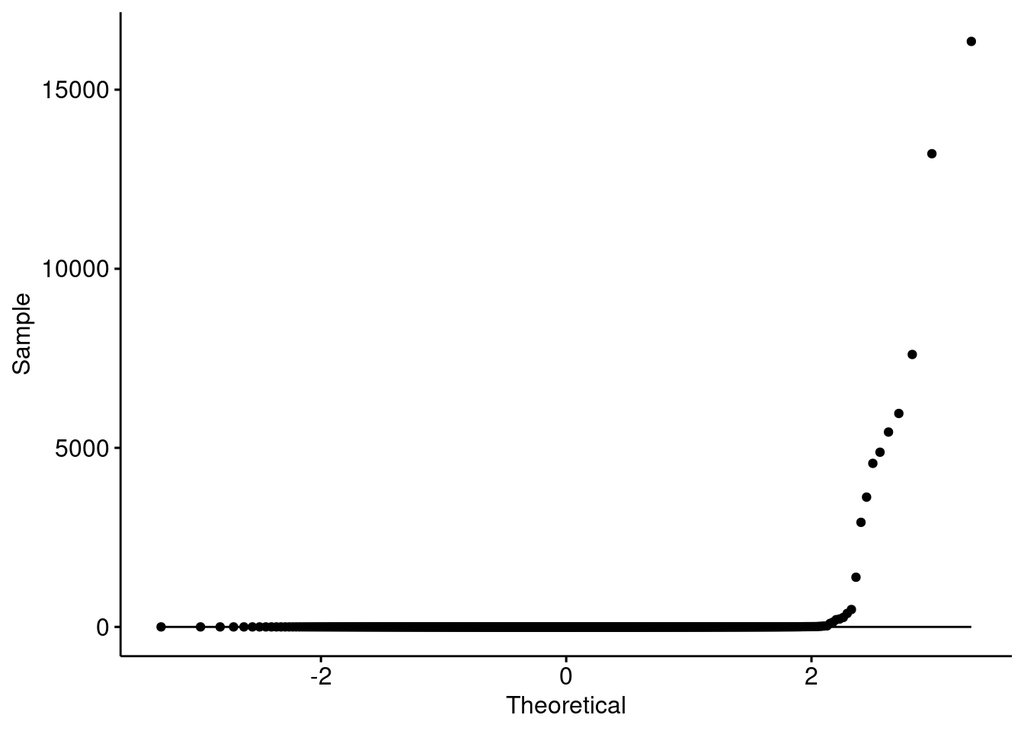

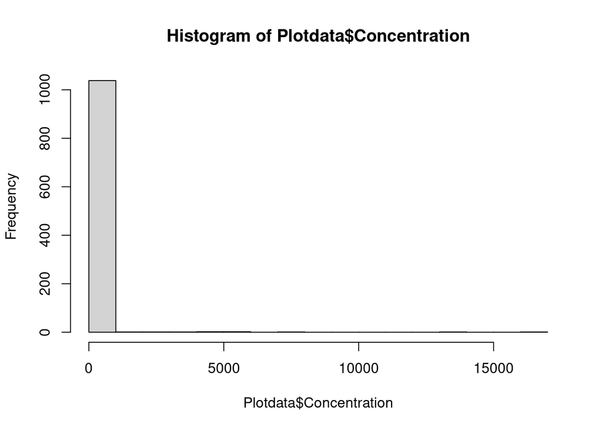

Results show the following restrictions

- **zero-inflated** => distribution is heavily non-normal, so excludes the use of *Gaussian* models
- **continuous data** => excludes the use of *Poisson* models
- data is very heavily **right-skewed**, extreme values inflating the mean => *Gamma* is also unstable here

=> to account for unique data distribution and values, i chose a modified **Hurdle model** approach https://m-clark.github.io/models-by-example/hurdle.html

I separated analyses into testing sample effect on

1. DETECTION: whether sample type had an effect on a sample detecting any target or not -> Binomial GLM
2. ABUNDANCE: whether sample type had an effect on the concentration among samples with detections -> Tweedie GLM

## DETECTION

Added variable for detection, binomial (0,1) for Concentration = 0 OR >0

```r
Plotdata <- Plotdata %>%
  mutate(detected = ifelse(Concentration > 0, 1, 0))

str(Plotdata)
```

```
## tibble [1,048 × 7] (S3: tbl_df/tbl/data.frame)
##  $ ...1         : num [1:1048] 1 2 3 4 5 6 7 8 11 12 ...
##  $ Target.Name  : chr [1:1048] "Adenovirus" "Enterovirus" "Influenza A" "Influenza B" ...
##  $ school       : chr [1:1048] "G" "G" "G" "G" ...
##  $ sample.type  : chr [1:1048] "A" "A" "A" "A" ...
##  $ date.order   : num [1:1048] 1 1 1 1 1 1 1 1 1 1 ...
##  $ Concentration: num [1:1048] 0 0 0 0.052 0 0 0 0.176 0 0 ...
##  $ detected     : num [1:1048] 0 0 0 1 0 0 0 1 0 0 ...
##  - attr(*, "na.action")= 'omit' Named int [1:260] 9 10 19 20 29 30 49 50 59 60 ...
##   ..- attr(*, "names")= chr [1:260] "9" "10" "19" "20" ...
```

```r
Plotdata$detected<-as.factor(Plotdata$detected)
summary(Plotdata$detected)
```

```
##   0   1
## 780 268
```

```r
table(Plotdata$sample.type, Plotdata$detected == 1)
```

```
##
##     FALSE TRUE
##   A   277  107
##   S   290   86
##   T   213   75
```

[output not shown]

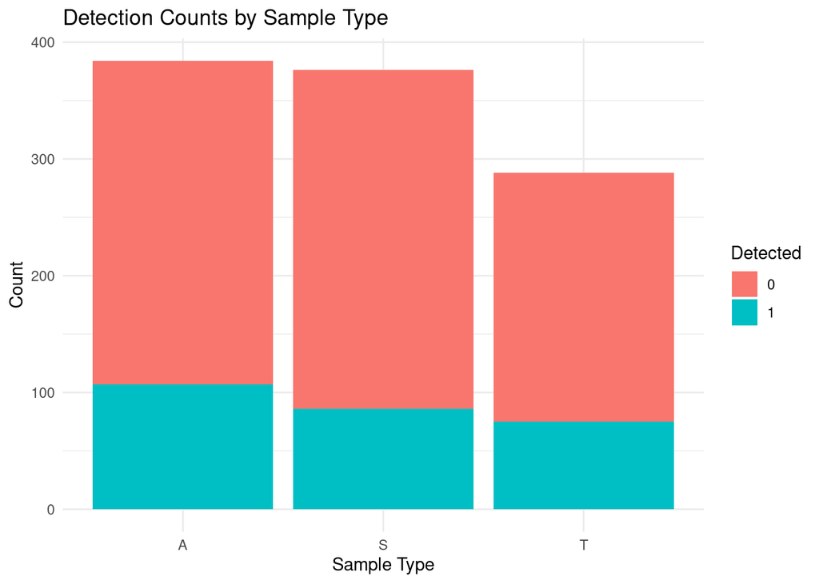

```r
SampleComp_Abund_detect_mod<-glm(detected~sample.type, data= Plotdata, family = binomial)
summary(SampleComp_Abund_detect_mod)
```

[output not shown]

**Sample type did not have an effect on detection levels in samples**

## ABUNDANCE

I separated all positive detections (Concentration > 0) into a separate dataframe

```r
Plotdata_conc <- Plotdata %>%
  filter(Concentration > 0)
str(Plotdata_conc)
```

```
## tibble [268 × 7] (S3: tbl_df/tbl/data.frame)
##  $ ...1         : num [1:268] 4 8 18 23 26 27 28 38 57 66 ...
##  $ Target.Name  : chr [1:268] "Influenza B" "SARS-CoV-2" "SARS-CoV-2" "Influenza A" ...
##  $ school       : chr [1:268] "G" "G" "G" "G" ...
##  $ sample.type  : chr [1:268] "A" "A" "S" "T" ...
##  $ date.order   : num [1:268] 1 1 1 1 1 1 1 1 1 1 ...
##  $ Concentration: num [1:268] 0.052 0.176 0.107 375.4 5.556 ...
##  $ detected     : Factor w/ 2 levels "0","1": 2 2 2 2 2 2 2 2 2 2 ...
##  - attr(*, "na.action")= 'omit' Named int [1:260] 9 10 19 20 29 30 49 50 59 60 ...
##   ..- attr(*, "names")= chr [1:260] "9" "10" "19" "20" ...
```

```r
summary(Plotdata_conc$Concentration)
```

```
##      Min.   1st Qu.    Median      Mean   3rd Qu.      Max.
##     0.035     0.054     0.108   253.494     0.375 16348.400
```

Summary of Concentration shows data is heavily skewed, with a few extremes inflating the mean, while median is very low I therefore tested two different approaches to building a model

### Log-transform + Linear regression

This follows the traditional recommendation of a Hurdle model by doing a linear regression after the binomial.

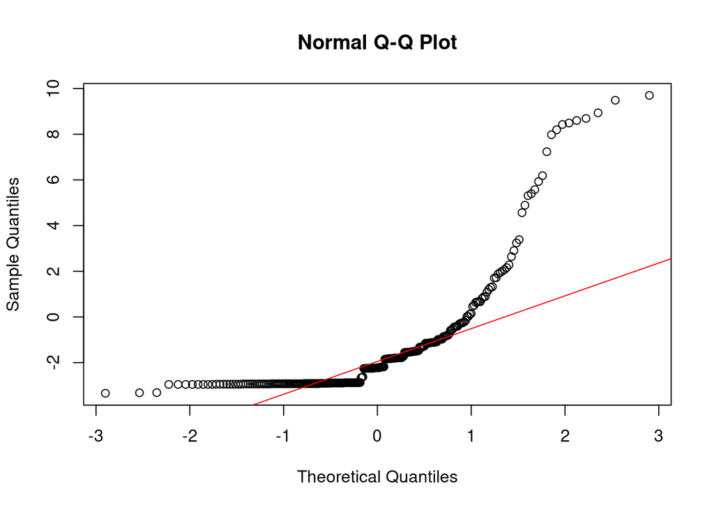

```r
Plotdata_conc <- Plotdata_conc %>% mutate(log_conc = log(Concentration))

qqnorm(Plotdata_conc$log_conc)
qqline(Plotdata_conc$log_conc, col = 'red')
```

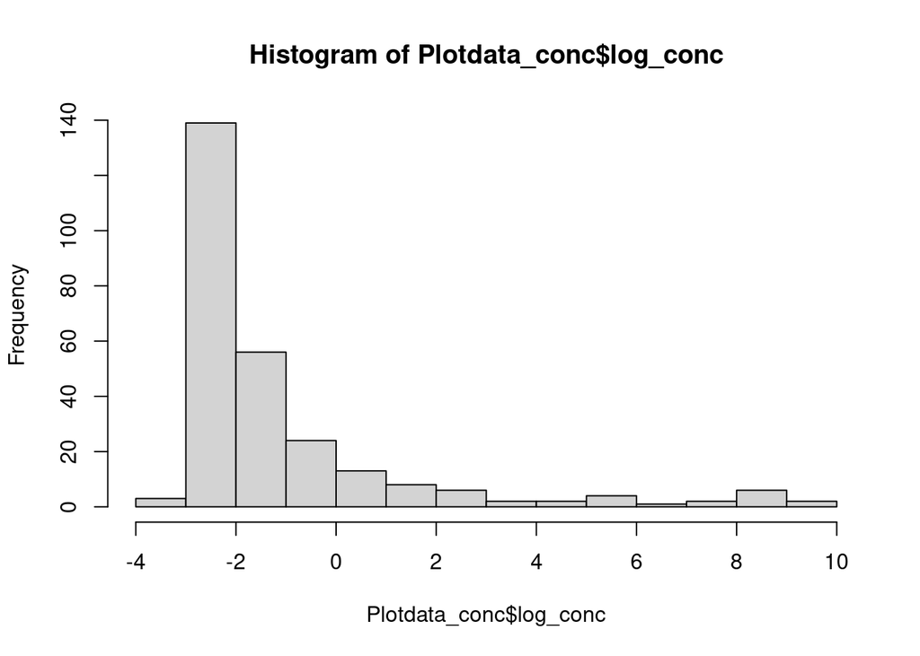

```r
hist(Plotdata_conc$log_conc)
```

```r
summary(Plotdata_conc$log_conc)
```

```
##    Min. 1st Qu.  Median    Mean 3rd Qu.    Max.
## -3.3429 -2.9188 -2.2303 -1.2519 -0.9805  9.7019
```

Unfortunately, transformation doesn’t create a Gaussian distribution for the transformed variable, so linear regression cannot be done

### Tweedie GLM

Family of distributions that are continuous but mass at zero, and can model a range of data distributions. https://search.r-project.org/CRAN/refmans/statmod/html/tweedie.html Also used for surveying viral data https://academic.oup.com/jrsssa/article/180/1/45/7068195

Tweedie GLMs allow for

1. setting different **variance of power** for controling the relationship between the mean and variance

| var.power | Response distribution |
| --- | --- |
| 0 | Normal |
| 1 | Poisson |
| 1,2 | Compound Poisson, non-negative with mass at zero |
| 2 | Gamma |
| 3 | Inverse-Gaussian |
| > 2 | Stable, with support on the positive reals |

2. setting different **link.power** defining relationship between linear predictor and mean

| link.power | Link function |
| --- | --- |
| 0 | log link |
| 1 | identity link |

```r
SampleComp_Abund_Conc_mod <- glm(Concentration ~ sample.type,
                   family = tweedie(var.power = 1.5, link.power = 0),
                   data = Plotdata_conc)
summary(SampleComp_Abund_Conc_mod)
```

```
##
## Call:
## glm(formula = Concentration ~ sample.type, family = tweedie(var.power = 1.5,
##     link.power = 0), data = Plotdata_conc)
##
## Coefficients:
##              Estimate Std. Error t value Pr(>|t|)
## (Intercept)   -1.0998     1.1580  -0.950    0.343
## sample.typeS   0.5308     1.6187   0.328    0.743
## sample.typeT   7.9074     1.1737   6.737    1e-10 ***
## ---
## Signif. codes:  0 '***' 0.001 '**' 0.01 '*' 0.05 '.' 0.1 ' ' 1
##
## (Dispersion parameter for Tweedie family taken to be 82.78742)
##
##     Null deviance: 25962  on 267  degrees of freedom
## Residual deviance: 10885  on 265  degrees of freedom
## AIC: NA
##
## Number of Fisher Scoring iterations: 6
```

Significant effect is detected for sample type, with tissue samples containing significantly higher concentrations in detected samples than air filter and swab samples

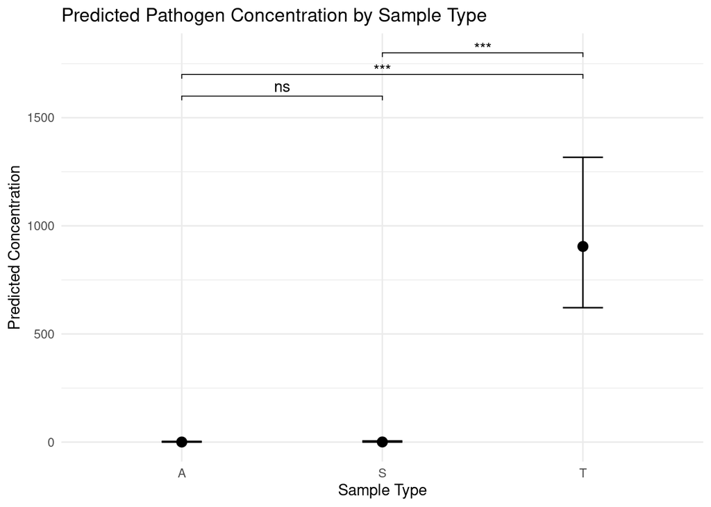